# Women Topic in Philosophy

# 1. Introduction

“It is clearly evident that women in philosophy still struggle for the right to be” (Devine, Stewart).Eventhough women in the history of philosophy are getting more attention, many scholars argue that historians of philosophy should acknowledge the influence of long-neglected female voices. The sexist views of well-known philosophers should not ignored on purpose. For instance, Aristotle, Polato and Hegel all once had negative viewpoints on women. Aristotle saw women as subject to men. By given the text data, I want to see What are different philosophy schools’ viewpoints on female? What are main topics when they discussed about women? And is Aristotle hostile to women?

# 2. Loading and Cleaning the data

|  | title | author | school | sentence_spacy | sentence_str | original_publication_date | corpus_edition_date | sentence_length | sentence_lowered | tokenized_txt | lemmatized_str |
| --- | --- | --- | --- | --- | --- | --- | --- | --- | --- | --- | --- |
| 1 | Plato - Complete Works | Plato | plato | What's new, Socrates, to make you leave your usual haunts in the Lyceum and spend your time here by the king archon's court? | What's new, Socrates, to make you leave your usual haunts in the Lyceum and spend your time here by the king archon's court? | -350 | 1997 | 125 | what's new, socrates, to make you leave your usual haunts in the lyceum and spend your time here by the king archon's court? | ['what', 'new', 'socrates', 'to', 'make', 'you', 'leave', 'your', 'usual', 'haunts', 'in', 'the', 'lyceum', 'and', 'spend', 'your', 'time', 'here', 'by', 'the', 'king', 'archon', 'court'] | what be new , Socrates , to make -PRON- leave -PRON- usual haunt in the Lyceum and spend -PRON- time here by the king archon 's court ? |
| 2 | Plato - Complete Works | Plato | plato | Surely you are not prosecuting anyone before the king archon as I am? | Surely you are not prosecuting anyone before the king archon as I am? | -350 | 1997 | 69 | surely you are not prosecuting anyone before the king archon as i am? | ['surely', 'you', 'are', 'not', 'prosecuting', 'anyone', 'before', 'the', 'king', 'archon', 'as', 'am'] | surely -PRON- be not prosecute anyone before the king archon as -PRON- be ? |
| 3 | Plato - Complete Works | Plato | plato | The Athenians do not call this a prosecution but an indictment, Euthyphro. | The Athenians do not call this a prosecution but an indictment, Euthyphro. | -350 | 1997 | 74 | the athenians do not call this a prosecution but an indictment, euthyphro. | ['the', 'athenians', 'do', 'not', 'call', 'this', 'prosecution', 'but', 'an', 'indictment', 'euthyphro'] | the Athenians do not call this a prosecution but an indictment , Euthyphro . |
| 4 | Plato - Complete Works | Plato | plato | What is this you say? | What is this you say? | -350 | 1997 | 21 | what is this you say? | ['what', 'is', 'this', 'you', 'say'] | what be this -PRON- say ? |
| 5 | Plato - Complete Works | Plato | plato | Someone must have indicted you, for you are not going to tell me that you have indicted someone else. | Someone must have indicted you, for you are not going to tell me that you have indicted someone else. | -350 | 1997 | 101 | someone must have indicted you, for you are not going to tell me that you have indicted someone else. | ['someone', 'must', 'have', 'indicted', 'you', 'for', 'you', 'are', 'not', 'going', 'to', 'tell', 'me', 'that', 'you', 'have', 'indicted', 'someone', 'else'] | someone must have indict -PRON- , for -PRON- be not go to tell -PRON- that -PRON- have indict someone else . |
| 6 | Plato - Complete Works | Plato | plato | But someone else has indicted you? | But someone else has indicted you? | -350 | 1997 | 34 | but someone else has indicted you? | ['but', 'someone', 'else', 'has', 'indicted', 'you'] | but someone else have indict -PRON- ? |

Because in this project, we mainly focus on women topic in Philosophy; therefore, we filter texts containing female keywords. The filtered datasets contains 8598 observations, and I use this dataset to do following analysis.

# 3. Data Processing

#### 3.1 Text Proprocessing

We select philosophy text data with female topic and to see text topics variation over different schools with emotions

|  | sentence_lowered | title | author | school | sentence_spacy | sentence_str | original_publication_date | corpus_edition_date | sentence_length | tokenized_txt | lemmatized_str |
| --- | --- | --- | --- | --- | --- | --- | --- | --- | --- | --- | --- |
| 1 | that truth is a woman | Beyond Good And Evil | Nietzsche | nietzsche | that Truth is a woman | that Truth is a woman | 1886 | 2003 | 22 | ['that', 'truth', 'is', 'woman'] | that truth be a woman |
| 2 | , a young woman, years of age, was in the habit of making tiles a day, with the assistance of little girls, who carried the clay for her, and stacked the tiles. | Capital | Marx | communism | , a young woman, years of age, was in the habit of making tiles a day, with the assistance of little girls, who carried the clay for her, and stacked the tiles. | , a young woman, years of age, was in the habit of making tiles a day, with the assistance of little girls, who carried the clay for her, and stacked the tiles. | 1883 | 1887 | 160 | ['young', 'woman', 'years', 'of', 'age', 'was', 'in', 'the', 'habit', 'of', 'making', 'tiles', 'day', 'with', 'the', 'assistance', 'of', 'little', 'girls', 'who', 'carried', 'the', 'clay', 'for', 'her… | , a young woman , year of age , be in the habit of make tile a day , with the assistance of little girl , who carry the clay for -PRON- , and stack the tile . |
| 3 | , both in staffordshire and in south wales young girls and women are employed on the pit banks and on the coke heaps, not only by day but also by night. | Capital | Marx | communism | , Both in Staffordshire and in South Wales young girls and women are employed on the pit banks and on the coke heaps, not only by day but also by night. | , Both in Staffordshire and in South Wales young girls and women are employed on the pit banks and on the coke heaps, not only by day but also by night. | 1883 | 1887 | 152 | ['both', 'in', 'staffordshire', 'and', 'in', 'south', 'wales', 'young', 'girls', 'and', 'women', 'are', 'employed', 'on', 'the', 'pit', 'banks', 'and', 'on', 'the', 'coke', 'heaps', 'not', 'only', 'by… | , both in Staffordshire and in South Wales young girl and woman be employ on the pit bank and on the coke heap , not only by day but also by night . |
| 4 | , for men, centimes for women, centimes for boys, and centimes for girls. | Capital | Marx | communism | , for men, centimes for women, centimes for boys, and centimes for girls. | , for men, centimes for women, centimes for boys, and centimes for girls. | 1883 | 1887 | 73 | ['for', 'men', 'centimes', 'for', 'women', 'centimes', 'for', 'boys', 'and', 'centimes', 'for', 'girls'] | , for man , centime for woman , centime for boy , and centime for girl . |
| 5 | , has been the sensual homage paid to beauty: to beauty of features; for it has been shrewdly observed by a german writer, that a pretty woman, as an object of desire, is generally allowed to be so by… | Vindication Of The Rights Of Woman | Wollstonecraft | feminism | , has been the sensual homage paid to beauty: to beauty of features; for it has been shrewdly observed by a German writer, that a pretty woman, as an object of desire, is generally allowed to be so by… | , has been the sensual homage paid to beauty: to beauty of features; for it has been shrewdly observed by a German writer, that a pretty woman, as an object of desire, is generally allowed to be so by… | 1792 | 2001 | 444 | ['has', 'been', 'the', 'sensual', 'homage', 'paid', 'to', 'beauty', 'to', 'beauty', 'of', 'features', 'for', 'it', 'has', 'been', 'shrewdly', 'observed', 'by', 'german', 'writer', 'that', 'pretty', 'w… | , have be the sensual homage pay to beauty : to beauty of feature ; for -PRON- have be shrewdly observe by a german writer , that a pretty woman , as an object of desire , be generally allow to be so … |
| 6 | , he not only makes it revolve around a form of torture originating in the orient, but also in this very field he causes his neurosis to oscillate between two poles constituted by the rich woman and t… | Anti-Oedipus | Deleuze | continental | , he not only makes it revolve around a form of torture originating in the Orient, but also in this very field he causes his neurosis to oscillate between two poles constituted by the rich woman and t… | , he not only makes it revolve around a form of torture originating in the Orient, but also in this very field he causes his neurosis to oscillate between two poles constituted by the rich woman and t… | 1972 | 1997 | 306 | ['he', 'not', 'only', 'makes', 'it', 'revolve', 'around', 'form', 'of', 'torture', 'originating', 'in', 'the', 'orient', 'but', 'also', 'in', 'this', 'very', 'field', 'he', 'causes', 'his', 'neurosis'… | , -PRON- not only make -PRON- revolve around a form of torture originate in the Orient , but also in this very field -PRON- cause -PRON- neurosis to oscillate between two pole constitute by the rich w… |

#### 3.2 Data Analysis: Process Variables for Analysis

In the following, I want to check whether women topic in philosophy becomes more popular. Whether there is an increased empirical research on women? So I drew 3 graphs here separately analyzed the weights of each school’s topic on women. First two barcharts show that school Feminism spent lots of time exploring women social positions. This is what we expect, but besides Feminism, Aristotle tends to have more texts related to women. In addition, in year 1949, female is a popular topic.

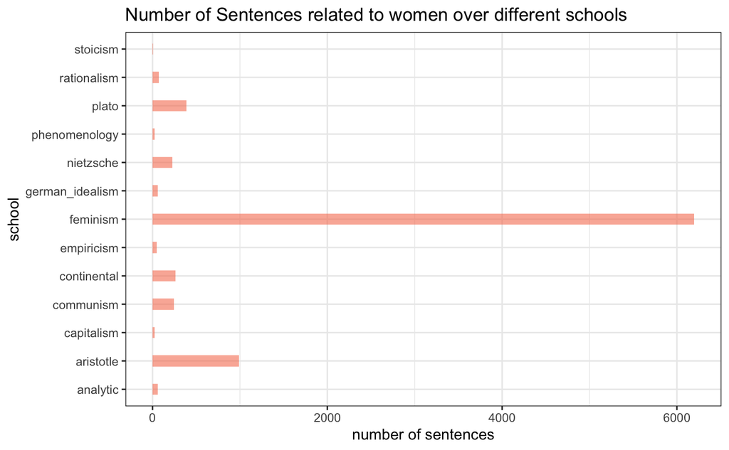

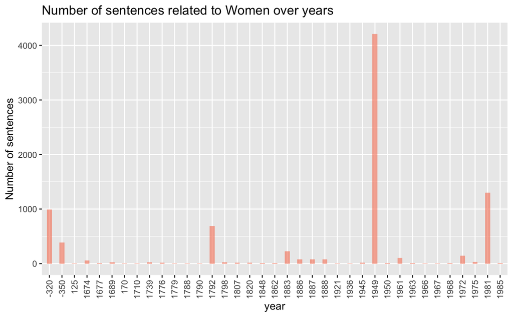

In addition, below graph clearly indicate different schools devote various length to the description of female. Feminism describe this field in details, and so do Plato, continental and Aristotle.

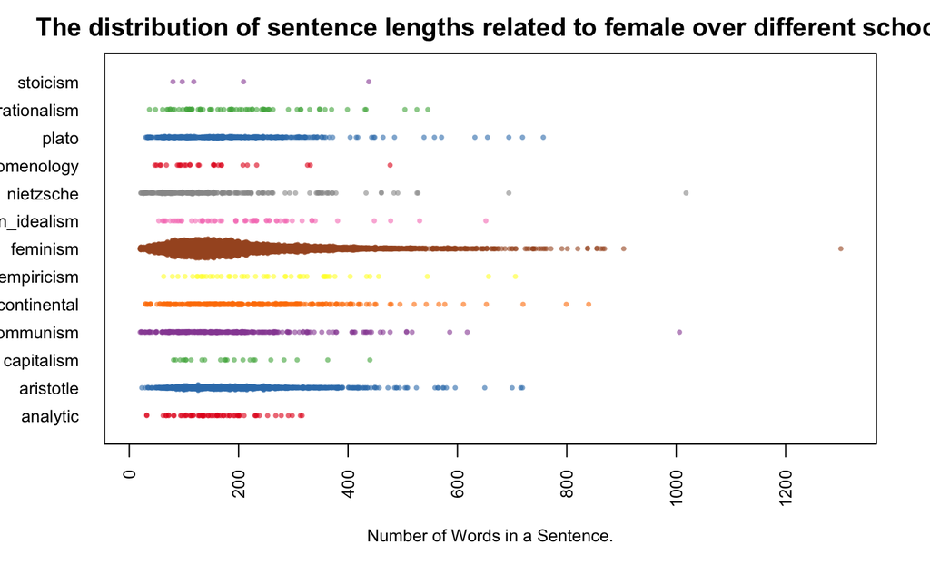

From above three graphs, we can see that on the question of women, many phisolophers show their arguments from different perspectives. They have large conversations there.

#### 3.3 Data Analysis: Sentiment Analysis

Sentiment analysis can help us determine whether the sentence is positive, negative or neutral. It is useful for us to gain an overview of all schools’ opinions behind certain topics. So we then do sentiment analysia so that we can see how philosophers shift between different sentiments.

|  | sentence_lowered | title | author | school | sentence_spacy | sentence_str | original_publication_date | corpus_edition_date | sentence_length | tokenized_txt | sentences | word.count | anger | anticipation | disgust | fear | joy | sadness | surprise | trust | negative | positive | sent.id |
| --- | --- | --- | --- | --- | --- | --- | --- | --- | --- | --- | --- | --- | --- | --- | --- | --- | --- | --- | --- | --- | --- | --- | --- |
| 1 | that truth is a woman | Beyond Good And Evil | Nietzsche | nietzsche | that Truth is a woman | that Truth is a woman | 1886 | 2003 | 22 | ['that', 'truth', 'is', 'woman'] | that truth is a woman | 5 | 0.00000000 | 0.00000000 | 0.00000000 | 0.00000000 | 0.00000000 | 0.00000000 | 0.00000000 | 0.19960080 | 0.00000000 | 0.19960080 | 1 |
| 2 | , a young woman, years of age, was in the habit of making tiles a day, with the assistance of little girls, who carried the clay for her, and stacked the tiles. | Capital | Marx | communism | , a young woman, years of age, was in the habit of making tiles a day, with the assistance of little girls, who carried the clay for her, and stacked the tiles. | , a young woman, years of age, was in the habit of making tiles a day, with the assistance of little girls, who carried the clay for her, and stacked the tiles. | 1883 | 1887 | 160 | ['young', 'woman', 'years', 'of', 'age', 'was', 'in', 'the', 'habit', 'of', 'making', 'tiles', 'day', 'with', 'the', 'assistance', 'of', 'little', 'girls', 'who', 'carried', 'the', 'clay', 'for', 'her… | , a young woman, years of age, was in the habit of making tiles a day, with the assistance of little girls, who carried the clay for her, and stacked the tiles. | 31 | 0.00000000 | 0.03224766 | 0.00000000 | 0.00000000 | 0.03224766 | 0.00000000 | 0.03224766 | 0.00000000 | 0.00000000 | 0.06449532 | 1 |
| 3 | , both in staffordshire and in south wales young girls and women are employed on the pit banks and on the coke heaps, not only by day but also by night. | Capital | Marx | communism | , Both in Staffordshire and in South Wales young girls and women are employed on the pit banks and on the coke heaps, not only by day but also by night. | , Both in Staffordshire and in South Wales young girls and women are employed on the pit banks and on the coke heaps, not only by day but also by night. | 1883 | 1887 | 152 | ['both', 'in', 'staffordshire', 'and', 'in', 'south', 'wales', 'young', 'girls', 'and', 'women', 'are', 'employed', 'on', 'the', 'pit', 'banks', 'and', 'on', 'the', 'coke', 'heaps', 'not', 'only', 'by… | , both in staffordshire and in south wales young girls and women are employed on the pit banks and on the coke heaps, not only by day but also by night. | 30 | 0.00000000 | 0.03332223 | 0.00000000 | 0.00000000 | 0.03332223 | 0.00000000 | 0.03332223 | 0.00000000 | 0.00000000 | 0.03332223 | 1 |
| 4 | , for men, centimes for women, centimes for boys, and centimes for girls. | Capital | Marx | communism | , for men, centimes for women, centimes for boys, and centimes for girls. | , for men, centimes for women, centimes for boys, and centimes for girls. | 1883 | 1887 | 73 | ['for', 'men', 'centimes', 'for', 'women', 'centimes', 'for', 'boys', 'and', 'centimes', 'for', 'girls'] | , for men, centimes for women, centimes for boys, and centimes for girls. | 12 | 0.00000000 | 0.00000000 | 0.00000000 | 0.00000000 | 0.00000000 | 0.00000000 | 0.00000000 | 0.00000000 | 0.00000000 | 0.00000000 | 1 |
| 5 | , has been the sensual homage paid to beauty: to beauty of features; for it has been shrewdly observed by a german writer, that a pretty woman, as an object of desire, is generally allowed to be so by… | Vindication Of The Rights Of Woman | Wollstonecraft | feminism | , has been the sensual homage paid to beauty: to beauty of features; for it has been shrewdly observed by a German writer, that a pretty woman, as an object of desire, is generally allowed to be so by… | , has been the sensual homage paid to beauty: to beauty of features; for it has been shrewdly observed by a German writer, that a pretty woman, as an object of desire, is generally allowed to be so by… | 1792 | 2001 | 444 | ['has', 'been', 'the', 'sensual', 'homage', 'paid', 'to', 'beauty', 'to', 'beauty', 'of', 'features', 'for', 'it', 'has', 'been', 'shrewdly', 'observed', 'by', 'german', 'writer', 'that', 'pretty', 'w… | , has been the sensual homage paid to beauty: to beauty of features; for it has been shrewdly observed by a german writer, that a pretty woman, as an object of desire, is generally allowed to be so by… | 75 | 0.01333156 | 0.03999467 | 0.01333156 | 0.01333156 | 0.05332622 | 0.01333156 | 0.01333156 | 0.02666311 | 0.02666311 | 0.09332089 | 1 |
| 6 | , he not only makes it revolve around a form of torture originating in the orient, but also in this very field he causes his neurosis to oscillate between two poles constituted by the rich woman and t… | Anti-Oedipus | Deleuze | continental | , he not only makes it revolve around a form of torture originating in the Orient, but also in this very field he causes his neurosis to oscillate between two poles constituted by the rich woman and t… | , he not only makes it revolve around a form of torture originating in the Orient, but also in this very field he causes his neurosis to oscillate between two poles constituted by the rich woman and t… | 1972 | 1997 | 306 | ['he', 'not', 'only', 'makes', 'it', 'revolve', 'around', 'form', 'of', 'torture', 'originating', 'in', 'the', 'orient', 'but', 'also', 'in', 'this', 'very', 'field', 'he', 'causes', 'his', 'neurosis'… | , he not only makes it revolve around a form of torture originating in the orient, but also in this very field he causes his neurosis to oscillate between two poles constituted by the rich woman and t… | 53 | 0.01886437 | 0.01886437 | 0.01886437 | 0.03772873 | 0.00000000 | 0.03772873 | 0.00000000 | 0.03772873 | 0.05659310 | 0.00000000 | 1 |

# 4. Data Analysis - Topic Modeling

## 4.1 Topic Modeling

We first performed text mining and text basic processing, then I generate document-term matrices and run LDA. For topic modeling, I prepare a corpus of sentence snipets as follows: I remove punctuation, lowercase, common(nonsense) words, duplicate key words and blankspaces. I set to select 15 topic groups, and it is shown in the following:

Based on the most popular terms and the most salient terms for each topic, we assign a hashtag to each topic: c(“temporal”, “society_role”, “action”, “demand”, “sex”, “doubt”, “perception”, “moral”, “equality”, “freedom”, “family_role”, “virgin”, “love”, “desire”, “ethic”).

[output not shown]

```r
ldaOut.terms
```

Here, I manually assign a hashtag to each topic. It is objective and might not be accurately correct.

## 4.2 Clustering of topics

Below the heat map shows the correlationmatrix between each school with 6 hashtags of topics.

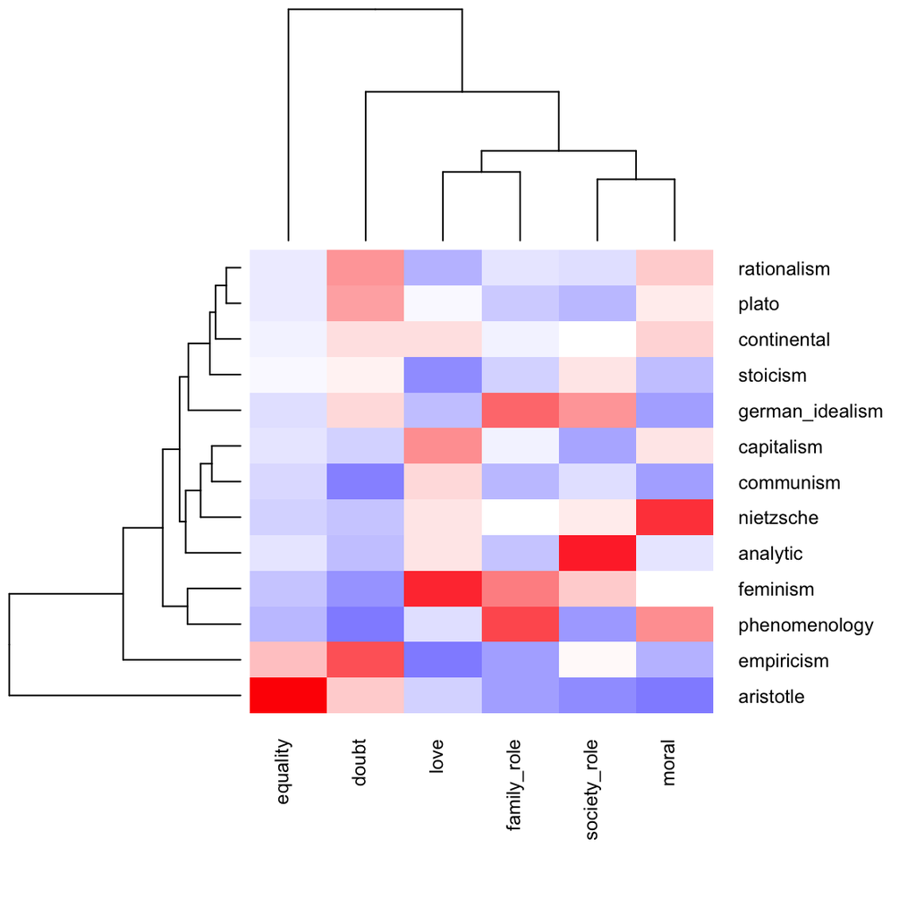

# 5. Aristotle’s views on Women

## 5.1 Is Aristotle hostile to women?

I then select emotionally charged sentences from Aristotle. Here are some examples: Aristotle school use words like evil, affliction, pain and confusion to describe women.These are all negative words.

```
[1] "aristotle "
```

```r
as.character(A.df$sentence_lowered[apply(A.df[,-1], 2, which.max)])
```

```
[1] "the evil showed itself in the theban invasion, when, unlike the women in other cities, they were utterly useless and caused more confusion than the enemy."
[2] "or is it because the male takes a long time to attain perfection, the female a short time?"
[3] "hence in some women the affliction"
[4] "female not without pain"
[5] "is it because in each species the young resembles the female of the same kind?"
[6] "female not without pain"
[7] "why are males usually larger than females?"
[8] "as a general rule these birds show this conjugal fidelity, but occasionally a female will cohabit with other than her mate."
```

## 5.2 Comparing Aristotle’s sentences to Feminism’s

In order to more objectively see whether Aristotle has bias on female, I also select emotional changed sentences from school feminism. While school feminism used words like sweet, humble to reflect girls. By comparison, we can clearly see that Aristotle underestimate woman’s role in the society.

```
[1] "feminism "
```

```r
as.character(f.df$sentence_lowered[apply(f.df[,-1], 2, which.max)])
```

```
[1] "for woman, man's sleep is avarice and betrayal." ": are girls anxious to marry?"
[3] "for woman, man's sleep is avarice and betrayal." ": are girls anxious to marry?"
[5] "girls are eager to marry %)."                    "sweet, humble, resigned as a woman"
[7] "girls are eager to marry %)."                    "girls are eager to marry %)."
```

Furthermore, I am interested in what are high frequency words that Aristotle school mostly used to describe a woman. So then I perform sentiment analysis and drew a wordcloud to intuitively see those keywords.

#Sentiment Analysis

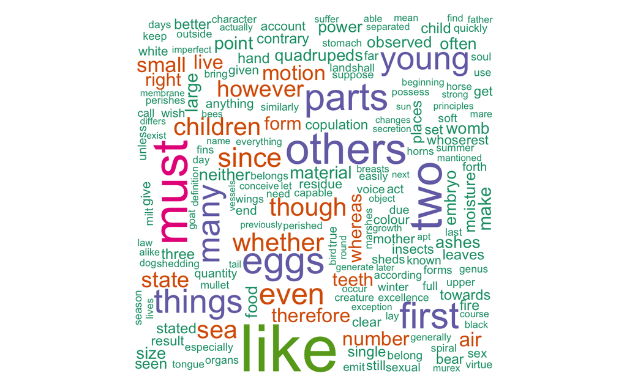

```r
set.seed(2021)

tmd_AP <- TermDocumentMatrix(clean_AP)
tmd_AP <- as.matrix(tmd_AP)
w_AP <- sort(rowSums(tmd_AP), decreasing = TRUE)

AP_freq_w <- subset(w_AP, w_AP>=20)

wordcloud(words = names(AP_freq_w),
          freq = AP_freq_w,
          colors = brewer.pal(10, 'Dark2'),
          scale = c(8,0.3))
```

```r
test_A <- grepl("organ|seman", AP_text)
AP_text <- AP_text[test_A]
AP_text[7]
```

```
[1] "all these organs are similar in the female; for there is no difference in regard to the internal organs, except in respect to the womb."
```

From this example, we can see that for Aristotle, women’s purpose is to give birth to children. His opinion is biased and not acceptable in today’s world.

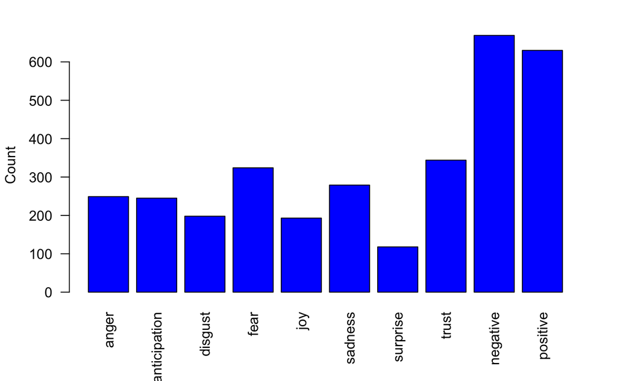

```r
#Sentiment bar chart
#obtain sentiment score
fel_text <- iconv(clean_AP, to = 'utf-8-mac')

s <- get_nrc_sentiment(fel_text)


barplot(colSums(s),
        las = 2,
        col = 'blue',
        ylab = 'Count')
```

The bar plot shows the count of words in the text, associated with each emotion. Negative emotions in Aristotle’s text appear more oftern. This bar chart demonstrates that words associated with the negative emotion occurred about six hundred times in the text, whereas words associated with the positive emotion of “surprise” occurred less than 200 times.From sentiment bar chart, it reflects emotions classification, we could see that besides two highest bars of negative and positive, most school Aristotle’s sentences contain words which have sentiments such as fear, sadness and trust.